# Lab 7_Categorical_SP2026_KEY

**Please see below for answers to all parts of Lab 7. Note, I provide you one way to do the code - there are others. That said, all code relates to the topic of the week - categorical data analysis**

**Scoring Summary**

- 10 points = submission to Github
  - **You must upload the QMD and HTML for full credit**
- 5 points = Code that runs (no errors, all chunks visible)
- 5 points = Correct answers. (Regardless of code)

# Answers

Remember, this week I asked you to write a mini report with embedded text. You each may have separate research question(s), but full credit will go to those who utilized the skills learned from class in combination with valid interpretation.

```r
edible_plants <- readr::read_csv('https://raw.githubusercontent.com/rfordatascience/tidytuesday/main/data/2026/2026-02-03/edible_plants.csv')
head(edible_plants)
```

```
# A tibble: 6 × 20
  taxonomic_name       common_name cultivation sunlight water preferred_ph_lower
  <chr>                <chr>       <chr>       <chr>    <chr>              <dbl>
1 Pisum sativum        Pea         Legume      Full sun Very…                  6
2 Phaseolus coccineus  Beans (Run… Legume      Full sun Medi…                  6
3 Phaseolus vulgari    Beans (Fre… Legume      Full sun Medi…                  6
4 Vicia faba           Beans (Bro… Legume      Full su… Very…                  6
5 Brassica oleracea    Cabbage (S… Legume      Full sun High                   6
6 Brassica oleracea (… Broccoli    Brassica    Full su… Medi…                  6
# ℹ 14 more variables: preferred_ph_upper <dbl>, nutrients <chr>, soil <chr>,
#   season <chr>, temperature_class <chr>, temperature_germination <chr>,
#   temperature_growing <chr>, days_germination <chr>, days_harvest <chr>,
#   nutritional_info <chr>, energy <dbl>, sensitivities <chr>,
#   description <chr>, requirements <chr>
```

## Research Questions

1. What is the relationship between the amount of sunlight a plant prefers and the temperature class one may prefer?
2. What characteristics of edible plants covary together?

### Data Munging

```r
library(tidyverse)

subset <- edible_plants %>%
  select(where(is.character))

bivariate <- subset %>% select(sunlight, temperature_class) %>% drop_na()

multivariate <- subset %>% select(cultivation, sunlight, water, nutrients, soil, season, temperature_class) %>% drop_na()
```

### Bar Plot

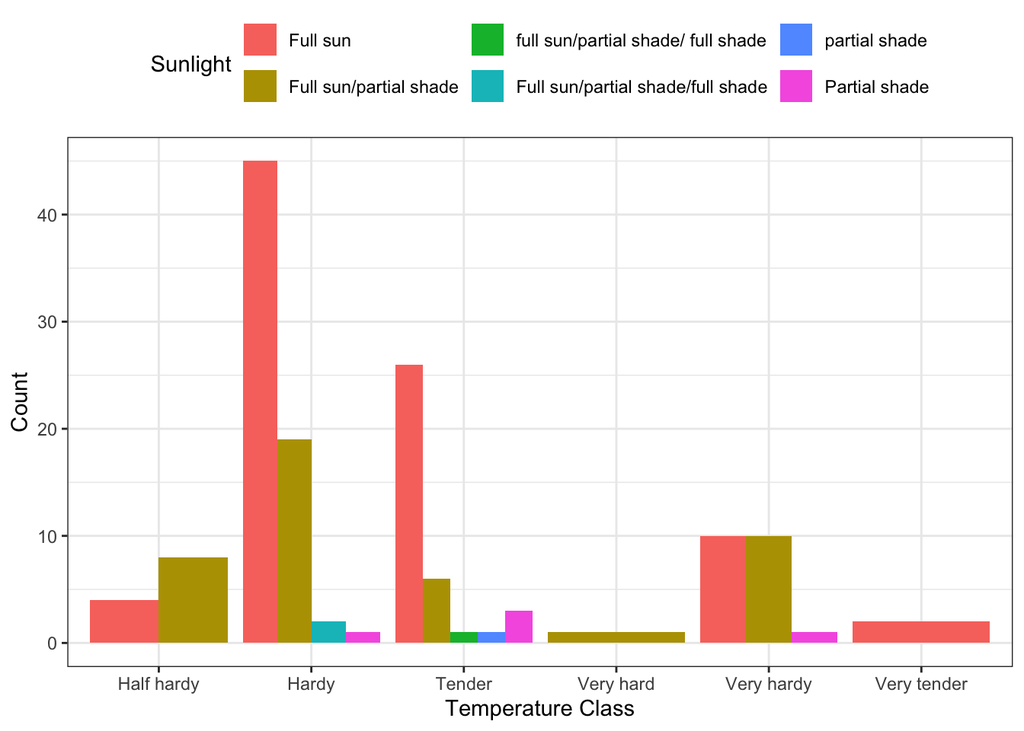

```r
bivariate %>% ggplot() + geom_bar(aes(x=temperature_class, fill=sunlight), position="dodge") + theme_bw() + labs(x="Temperature Class", y="Count", fill="Sunlight") + theme(legend.position = "top")
```

### Cramer’s V

There is a *moderate association* between sunlight and temperature class. The Cramer’s V values is 0.1961 with a degrees of freedom equal to 5.

```r
tab <- table(bivariate$sunlight, bivariate$temperature_class)
tab
```

```
                                     Half hardy Hardy Tender Very hard
  Full sun                                    4    45     26         0
  Full sun/partial shade                      8    19      6         1
  full sun/partial shade/ full shade          0     0      1         0
  Full sun/partial shade/full shade           0     2      0         0
  partial shade                               0     0      1         0
  Partial shade                               0     1      3         0

                                     Very hardy Very tender
  Full sun                                   10           2
  Full sun/partial shade                     10           0
  full sun/partial shade/ full shade          0           0
  Full sun/partial shade/full shade           0           0
  partial shade                               0           0
  Partial shade                               1           0
```

```r
rcompanion::cramerV(tab)
```

```
Cramer V
  0.1961
```

```r
# Degrees of Freedom
min(nrow(tab) - 1, ncol(tab) - 1)
```

```
[1] 5
```

### Cross Tabulation

```r
gmodels::CrossTable(bivariate$sunlight, bivariate$temperature_class)
```

```
   Cell Contents
|-------------------------|
|                       N |
| Chi-square contribution |
|           N / Row Total |
|           N / Col Total |
|         N / Table Total |
|-------------------------|


Total Observations in Table:  140


                                   | bivariate$temperature_class
                bivariate$sunlight |  Half hardy |       Hardy |      Tender |   Very hard |  Very hardy | Very tender |   Row Total |
-----------------------------------|-------------|-------------|-------------|-------------|-------------|-------------|-------------|
                          Full sun |           4 |          45 |          26 |           0 |          10 |           2 |          87 |
                                   |       1.603 |       0.272 |       0.393 |       0.621 |       0.713 |       0.461 |             |
                                   |       0.046 |       0.517 |       0.299 |       0.000 |       0.115 |       0.023 |       0.621 |
                                   |       0.333 |       0.672 |       0.703 |       0.000 |       0.476 |       1.000 |             |
                                   |       0.029 |       0.321 |       0.186 |       0.000 |       0.071 |       0.014 |             |
-----------------------------------|-------------|-------------|-------------|-------------|-------------|-------------|-------------|
            Full sun/partial shade |           8 |          19 |           6 |           1 |          10 |           0 |          44 |
                                   |       4.741 |       0.201 |       2.724 |       1.496 |       1.752 |       0.629 |             |
                                   |       0.182 |       0.432 |       0.136 |       0.023 |       0.227 |       0.000 |       0.314 |
                                   |       0.667 |       0.284 |       0.162 |       1.000 |       0.476 |       0.000 |             |
                                   |       0.057 |       0.136 |       0.043 |       0.007 |       0.071 |       0.000 |             |
-----------------------------------|-------------|-------------|-------------|-------------|-------------|-------------|-------------|
full sun/partial shade/ full shade |           0 |           0 |           1 |           0 |           0 |           0 |           1 |
                                   |       0.086 |       0.479 |       2.048 |       0.007 |       0.150 |       0.014 |             |
                                   |       0.000 |       0.000 |       1.000 |       0.000 |       0.000 |       0.000 |       0.007 |
                                   |       0.000 |       0.000 |       0.027 |       0.000 |       0.000 |       0.000 |             |
                                   |       0.000 |       0.000 |       0.007 |       0.000 |       0.000 |       0.000 |             |
-----------------------------------|-------------|-------------|-------------|-------------|-------------|-------------|-------------|
 Full sun/partial shade/full shade |           0 |           2 |           0 |           0 |           0 |           0 |           2 |
                                   |       0.171 |       1.136 |       0.529 |       0.014 |       0.300 |       0.029 |             |
                                   |       0.000 |       1.000 |       0.000 |       0.000 |       0.000 |       0.000 |       0.014 |
                                   |       0.000 |       0.030 |       0.000 |       0.000 |       0.000 |       0.000 |             |
                                   |       0.000 |       0.014 |       0.000 |       0.000 |       0.000 |       0.000 |             |
-----------------------------------|-------------|-------------|-------------|-------------|-------------|-------------|-------------|
                     partial shade |           0 |           0 |           1 |           0 |           0 |           0 |           1 |
                                   |       0.086 |       0.479 |       2.048 |       0.007 |       0.150 |       0.014 |             |
                                   |       0.000 |       0.000 |       1.000 |       0.000 |       0.000 |       0.000 |       0.007 |
                                   |       0.000 |       0.000 |       0.027 |       0.000 |       0.000 |       0.000 |             |
                                   |       0.000 |       0.000 |       0.007 |       0.000 |       0.000 |       0.000 |             |
-----------------------------------|-------------|-------------|-------------|-------------|-------------|-------------|-------------|
                     Partial shade |           0 |           1 |           3 |           0 |           1 |           0 |           5 |
                                   |       0.429 |       0.811 |       2.132 |       0.036 |       0.083 |       0.071 |             |
                                   |       0.000 |       0.200 |       0.600 |       0.000 |       0.200 |       0.000 |       0.036 |
                                   |       0.000 |       0.015 |       0.081 |       0.000 |       0.048 |       0.000 |             |
                                   |       0.000 |       0.007 |       0.021 |       0.000 |       0.007 |       0.000 |             |
-----------------------------------|-------------|-------------|-------------|-------------|-------------|-------------|-------------|
                      Column Total |          12 |          67 |          37 |           1 |          21 |           2 |         140 |
                                   |       0.086 |       0.479 |       0.264 |       0.007 |       0.150 |       0.014 |             |
-----------------------------------|-------------|-------------|-------------|-------------|-------------|-------------|-------------|
```

### Fisher’s Test

Here, I choose to use a Fisher’s Test because the data are sparse in certain categories. In other words, there are less than 5 counts across greater than 20% of the possible combinations of values.

There is a statistically significant association between sunlight required and temperature hardiness.

```r
janitor::fisher.test(bivariate$sunlight, bivariate$temperature_class, simulate.p.value=T)
```

```
    Fisher's Exact Test for Count Data with simulated p-value (based on
    2000 replicates)

data:  bivariate$sunlight and bivariate$temperature_class
p-value = 0.04898
alternative hypothesis: two.sided
```

### Multiple Correspondence Analysis

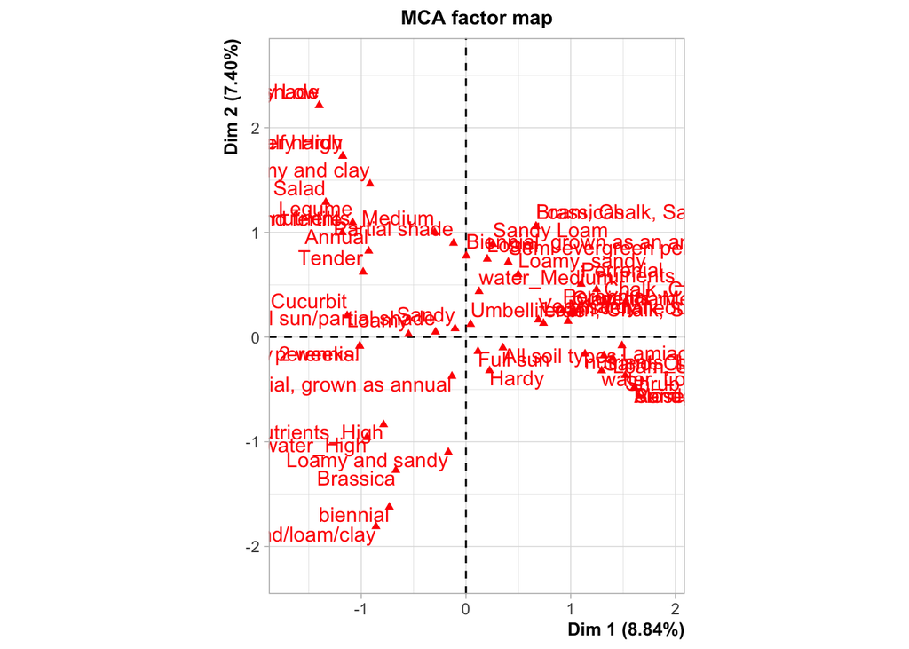

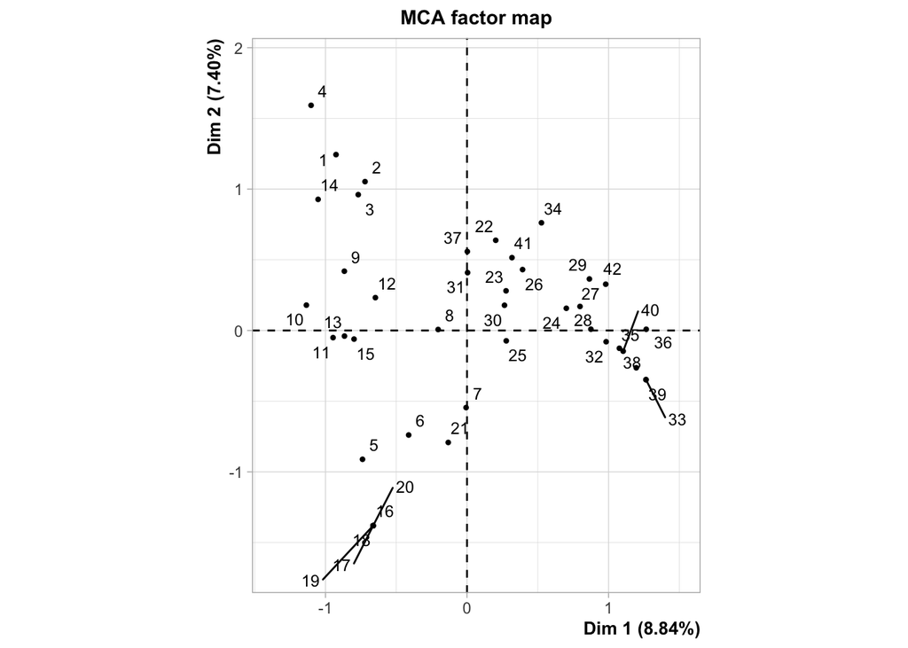

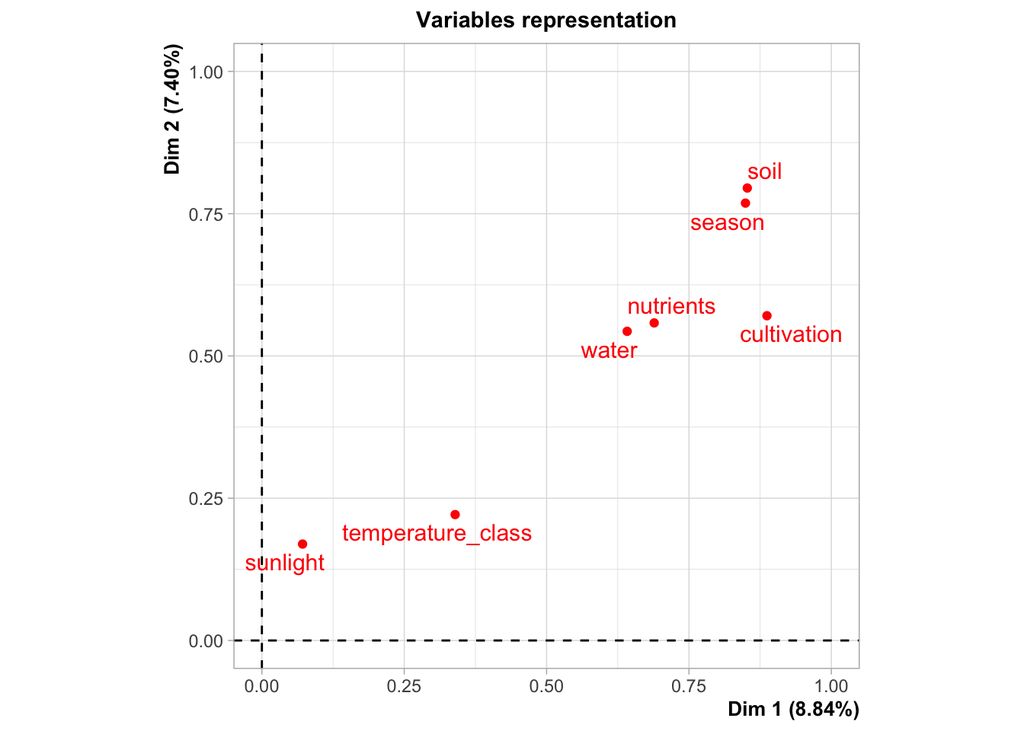

```r
library(factoextra)
library(FactoMineR)

res_mca <- MCA(multivariate)
```

```
Too few points to calculate an ellipse
Too few points to calculate an ellipse
Too few points to calculate an ellipse
```

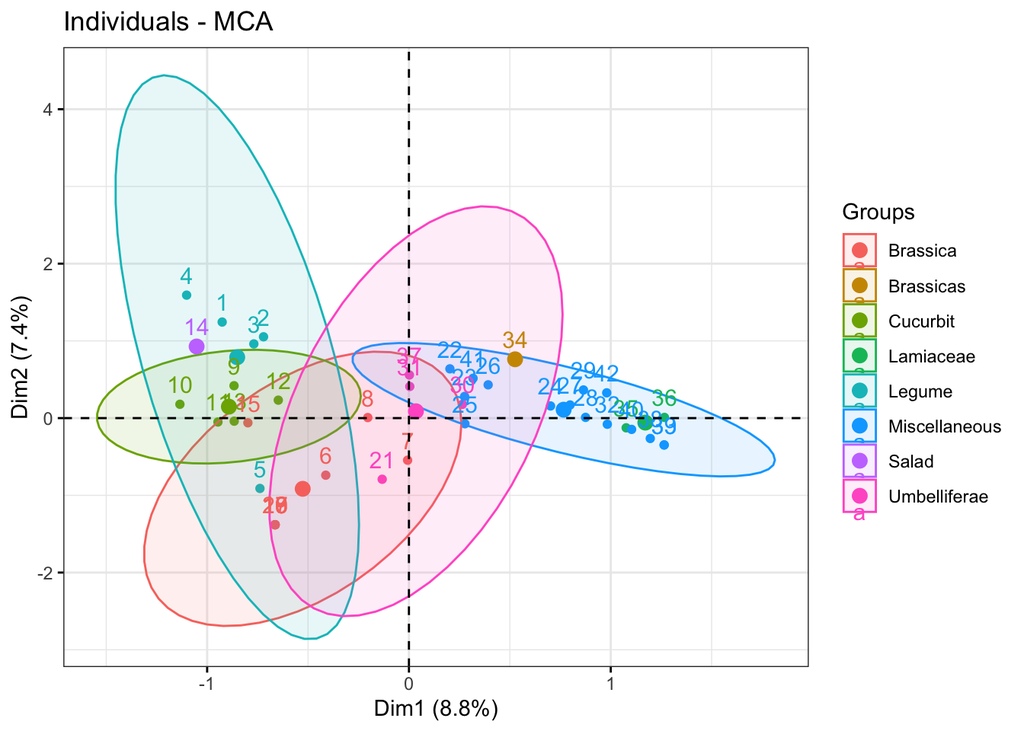

```r
fviz_mca_ind(res_mca, ggtheme=theme_bw(), habillage = as.factor(multivariate$cultivation), addEllipses = T)
```

### Interpretations

1. In the bivariate analysis, there does appear to be a statistically significant relationship between sunlight requirements and temperature hardiness. Caution should be taken because of the small sample sizes across the categories.
2. The MCA analyses corroborate the above analyses and show that there is a relationship between water and nutrient demands, the soil types and season of planting, and it appears most cultivation(s) follow these patterns. That said, sunlight and temperature appear slightly offset indicating variability across categories. There is no clear pattern by cultivation type as all categories / ellipses overlap in the individual plot with ellipses.